# Mise en place de Consul

Docker embarque un serveur DNS pour découvrir les conteneurs sur un même réseau Docker. Ce serveur a cependant plusieurs limitations :

- il ne permet pas de découvrir facilement plusieurs instances d’un service
- il ne fonctionne qu’avec les conteneurs locaux de la machine, pas ceux d’une machine distante

Dans ce TP, nous allons utiliser Consul et son serveur DNS intégré pour découvrir les différentes instances de chaque service.

Les machines de TP ont été préparées avec une installation de Consul et de Docker à jour. Le but n’étant pas de se concentrer sur leur mise en place, un serveur Consul est déjà configuré sur chaque machine.

Cette section décrit comment Consul a été configuré, pour vous permettre de comprendre comment il fonctionne. N’hésitez pas à vous prendre le temps de regarder tous les fichiers de configuration cités dans cette section !

## Installation de Consul

Consul a été installé depuis les binaires disponibles sur https://www.consul.io/downloads.html.

Le binaire se trouve dans `/usr/local/bin/consul`, et il y a un service systemd défini dans `/etc/systemd/system/consul.service`. Ce service lance l’agent sous l’utilisateur `consul`, en utilisant les fichiers de configuration présents dans `/etc/consul.d`.

Vous pouvez vérifier l’état du service avec `systemctl status consul.service`, et le redémarrer avec `systemctl restart consul.service`. Les logs de Consul sont accessibles via `journalctl -xfu consul.service`.

Vérifiez que vous avez bien accès à l’interface de Consul sur http://consul.service.consul.:8500 ou sur http://localhost:8500.

Vous devriez également pouvoir utiliser l’outil en ligne de commande `consul`, par exemple, pour lister les services enregistrés : `consul catalog services`.

Enfin, le serveur DNS de Consul devrait fonctionner: vous pouvez vérifier avec `dig +noall +answer SRV consul.service.consul.`.

## Installation de Docker

L’installation de Docker a été faite en suivant les instructions disponibles sur https://docs.docker.com/engine/install/ubuntu/. Votre utilisateur a été ajouté au groupe `docker` pour pouvoir lancer des conteneurs sans basculer en `root` (via `sudo`, par exemple).

Vérifiez que vous arrivez bien à communiquer au démon Docker avec `docker info`.

## Utilisation du serveur DNS de Consul

Par défaut, les conteneurs lancés par Docker vont utiliser le serveur DNS configuré sur la machine hôte. Il a donc fallu configurer l’hôte pour utiliser le serveur DNS de Consul pour les noms `*.consul`.

La documentation de Consul à ce sujet sur différentes plateformes: https://learn.hashicorp.com/tutorials/consul/dns-forwarding

Les machines de TPs utilisent `systemd-resolved` pour la résolution de noms. Pour que cela fonctionne, on a créé une nouvelle interface `dummy0`, dont le fichier de configuation est disponible dans `/etc/systemd/network/dummy0.network`. Docker a ensuite été configuré pour utilisé l’IP sur cette interface comme serveur DNS pour les conteneurs (cf. `/etc/docker/daemon.json`).

# Présentation de l’application

Dans ce TP, nous allons déployer une application avec deux composants : un serveur web et un exécuteur de tâches.

Cette application sert une petite API qui télécharge des pages HTML pour en extraire leur titre (balise `<title>`). Le serveur web va donc prendre une liste d’URLs en entrée et demander aux exécuteurs de tâches pour chaque URL de récupérer le titre de la page.

Les deux componsants sont dit “scalables” horizontalement. Le but de ce TP est :

- dans un premier temps, déployer les différents composants de l’application via Docker
- ensuite, scripter l’ajout de différentes instances de l’exécuteur de tâches et du serveur web
- ajouter un répartiteur de charges devant les serveurs web
- automatiquement reconfigurer le répartiteur de charge lors de l’ajout et de la supression d’instances du serveur web

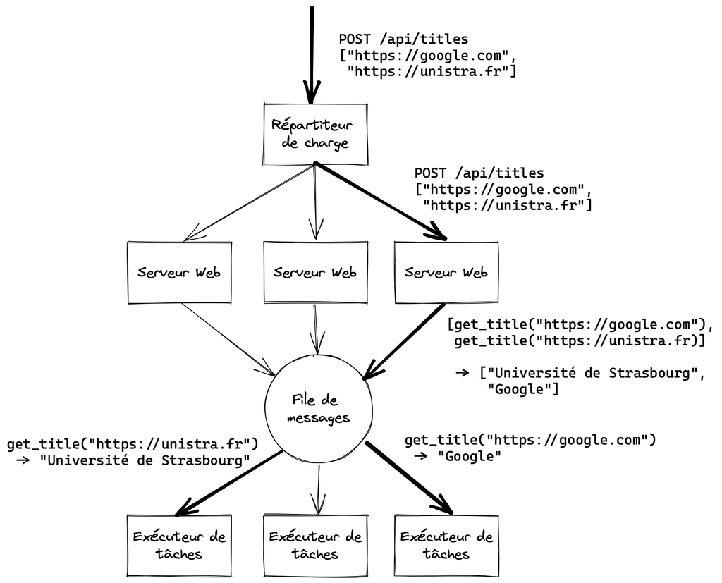

La vie d’une requête à l’API dans l’application

Le code de l’application est disponible à l’adresse : https://github.com/sandhose/tp-siris-service-discovery

## Essayer l’application avec `docker-compose`

L’application comprend une configuration `docker-compose` qui déploie une instance du serveur web, un base de données Redis et une instance de l’exécuteur de tâches.

```bash
git clone https://github.com/sandhose/tp-siris-service-discovery.git app
cd app
docker-compose pull
docker-compose up
```

Si votre utilisateur n’a pas le droit d’accéder à Docker, ajoutez le au groupe `docker`: `sudo usermod -aG docker $USER`

Navigez ensuite sur http://localhost:8080/.

**Stoppez et supprimez la pile `docker-compose` avec `docker-compose down`**. Pour le reste du TP, vous allez lancer les conteneurs sans `docker-compose`, à l’aide des commandes `docker run`, `create`, `start`, etc.

# Déployer Redis et l’enregistrer dans Consul

Le but est maintenant de lancer Redis avec Docker et de l’enregistrer auprès de Consul.

1. Lancez un conteneur à partir de l’image [`docker.io/library/redis:6.2`](https://hub.docker.com/_/redis)
2. Récupérez son adresse IP à l’aide de `docker inspect [nom|id]`
3. Enregistrez le service via `consul services register`
4. Automatisez/scriptez ces opérations
5. (optionnel) intégrez un *healthcheck* pour que Consul vérifie l’état de votre service

La manière dont vous scriptez ces opérations est libre. Consul et Docker offrent tous les deux une API documentée ainsi que des outils en ligne de commande.

Quelques indications si vous scriptez en faisant appel aux outils en ligne de commande :

- `docker run` et `docker create` retournent l’ID du conteneur créé. Récupérez-le pour ensuite l’utiliser dans d’autres commandes.
- `docker inspect` permet d’obtenir de nombreuses informations sur le conteneur. Toutes les informations sur le conteneur sont sorties au format JSON par défaut, mais le paramètre `--format` permet de cibler un champ en particulier

Références :

- https://www.consul.io/docs/discovery/services
- https://docs.docker.com/engine/reference/commandline/inspect/
- https://www.consul.io/docs/discovery/checks

# Déployer le serveur web et l’exécuteur de tâches

Maintenant que Redis fonctionne et est enregistré auprès de Consul, lancez les deux autres services en les faisant se connecter à Redis via son adresse dans Consul. Si votre service s’appelle `redis`, il devrait être accessible via `redis.service.consul`. Vous devez donc lancer les deux conteneurs avez les variables d’environnement suivantes :

- `CELERY_BROKER_URL=redis://redis.service.consul:6379/0`
- `CELERY_RESULT_BACKEND=redis://redis.service.consul:6379/1`

## Scriptez l’ajout d’exécuteurs de tâches

Vous pouvez lancer plusieurs exécuteurs de tâches en parallèle. Lancez-en plusieurs, et constatez que les tâches sont bien exécutées sur les différentes instances. L’API de l’application inclue le nom d’hôte du nœud ayant exécuté chaque tâche.

# Ajout d’un répartiteur de charge

Ajoutez le répartiteur de charge [`haproxy`](https://hub.docker.com/_/haproxy) devant le serveur web, avec la configuration suivante, en remplaçant l’IP par celle du contenenur du serveur web :

```
global
  daemon
  maxconn 1024

defaults
  balance roundrobin
  timeout client 60s
  timeout connect 60s
  timeout server 60s

frontend stats
  bind *:8404
  mode http
  stats enable
  stats uri /stats
  stats refresh 10s
  stats admin if TRUE

frontend http
  bind *:8080
  mode http
  default_backend web

backend web
  balance roundrobin
  mode http
  server web 172.10.0.2:8080
```

Dans cette configuration, `haproxy` sert le service web sur le port 8080, et une page de statistique sur http://localhost:8404/stats.

Références :

- https://hub.docker.com/_/haproxy
- https://github.com/docker-library/docs/tree/master/haproxy#directly-via-bind-mount
- https://www.haproxy.com/blog/exploring-the-haproxy-stats-page/

## Enregistrez les instances de serveur web auprès de Consul et scriptez l’ajout d’une nouvelle instance

De la même manière que pour le conteneur Redis, automatisez le lancement d’instances du serveur web, et leur enregistrement auprès de Consul. Le serveur web inclue une route `/health` qui peut permettre d’implémenter un *healthcheck*.

## Configuration dynamique

Utilisez [`consul-template`](https://github.com/hashicorp/consul-template) pour générer dynamiquement la configuration de `haproxy`. Vous pouvez signaler un changement dans la configuration à `haproxy` en lui envoyant un signal `SIGHUP` : `docker kill -s HUP [id-haproxy]`

Références :

- https://github.com/hashicorp/consul-template
- https://learn.hashicorp.com/tutorials/consul/consul-template#use-case-discover-all-services

# Stockage clé-valeur

Consul dispose également d’une base de donnée clé-valeur pour stocker de la configuration.

Exemple d’utilisation :

```bash
# Définie la valeur pour une clé
consul kv put haproxy/config/maxconn 1024
# Récupère la valeur d'une clé
consul kv get haproxy/config/maxconn
# Supprime une clé
consul kv delete haproxy/config/maxconn
```

Modifier votre configuration de `consul-template` pour pouvoir modifier dynamiquement le paramètre `maxconn` de `haproxy`.

Références :

- https://www.consul.io/commands/kv
- https://learn.hashicorp.com/tutorials/consul/consul-template#use-case-consul-kv